# Quick exploration of IGH regions

L. Collado-Torres

2/23/2017

## Setup

The following code loads the *RangedSummarizedExperiment* objects for each of the three main groups of data: SRA (almost 50,000 RNA-seq samples), GTEx and TCGA. We have separate objects because the metadata for GTEx and TCGA includes variables that are not present in SRA and because you might want to treat each dataset differently. After loading them, we normalize them to a library size of 40 million 100 bp reads using `scale_counts()` with the argument `round = FALSE` to keep fractional read counts.

```r
startTime <- Sys.time()
## Load libraries
library('SummarizedExperiment')
library('recount')
library('GenomicRanges')
library('ggplot2')
library('DT')
library('devtools')

## Load files
projects <- c('sra', 'TCGA', 'SRP012682')
rse <- lapply(projects, function(project) {
    load(paste0('rse_', project, '.Rdata'))

    ## Scale counts
    result <- scale_counts(rse, round = FALSE)
    return(result)
})
projects <- names(rse) <- c('SRA', 'TCGA', 'GTEx')
```

These counts are from 10 different regions from chr14. The following code visualizes the regions.

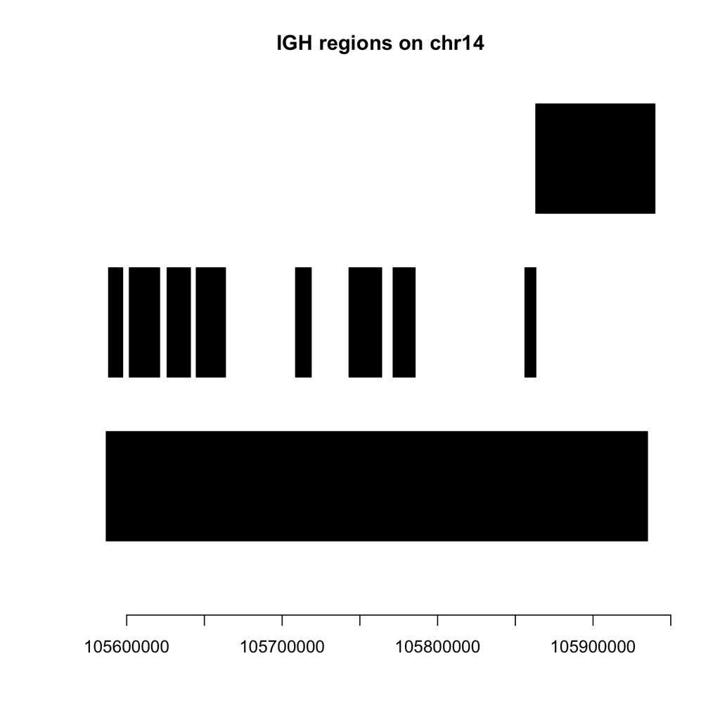

```r
regions <- rowRanges(rse[[1]])

## Taken from http://bioconductor.org/packages/release/bioc/vignettes/IRanges/inst/doc/IRangesOverview.R
plotRanges <- function(x, xlim = x, main = deparse(substitute(x)),
                       col = "black", sep = 0.5, ...)
{
  height <- 1
  if (is(xlim, "Ranges"))
    xlim <- c(min(start(xlim)), max(end(xlim)))
  bins <- disjointBins(IRanges(start(x), end(x) + 1))
  plot.new()
  plot.window(xlim, c(0, max(bins)*(height + sep)))
  ybottom <- bins * (sep + height) - height
  rect(start(x)-0.5, ybottom, end(x)+0.5, ybottom + height, col = col, ...)
  title(main)
  axis(1)
}

plotRanges(ranges(regions), main = 'IGH regions on chr14')
```

## Visualize counts

Now that we have the data loaded, we can visualize the counts. The first plot shows the $\log_{10}(counts + 1)$ and the second the $\log_2(RPKM + 1)$ distribution. Looks like there is plenty of data to look at.

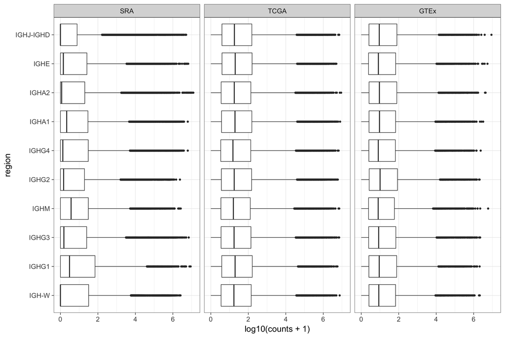

```r
## Construct a data.frame that will be easy to use with ggplot2
counts <- mapply(function(se, project) {
    df <- data.frame(
        counts = as.vector(assays(se)$counts),
        region = factor(rep(names(se), each = ncol(se)), levels = names(se)),
        project = rep(project, ncol(se) * nrow(se)),
        width = rep(width(regions), each = ncol(se))
    )
    return(df)
}, rse, projects, SIMPLIFY = FALSE)
counts <- do.call(rbind, counts)
rownames(counts) <- NULL

## Calculate RPKMs
## Formula: http://www.metagenomics.wiki/pdf/definition/rpkm-calculation
counts$RPKM <- counts$counts / (counts$width/1000 * 40)

ggplot(counts, aes(y = log10(counts + 1), x = region)) + geom_boxplot() +
    facet_grid(. ~ project) + coord_flip() + theme_bw(base_size = 18)
```

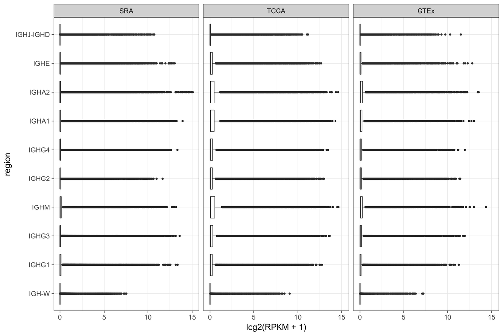

```r
ggplot(counts, aes(y = log2(RPKM + 1), x = region)) + geom_boxplot() +
    facet_grid(. ~ project) + coord_flip() + theme_bw(base_size = 18)
```

## Select studies

```r
## Looking at just IGH-W for SRA
igh_w_sra <- subset(counts, region == 'IGH-W' & project == 'SRA')
stopifnot(nrow(igh_w_sra) == ncol(rse[['SRA']]))

## Filter IGH-W data
has_data <- log2(igh_w_sra$RPKM + 1) > 0.1
has_data_by_project <- split(has_data, colData(rse[['SRA']])$project)
has_data_mean <- sapply(has_data_by_project, mean)

## Create table with proper ordering
studies <- data.frame(
    project = names(has_data_mean),
    percent_with_data = round(has_data_mean * 100, 2),
    n_samples = sapply(has_data_by_project, length)
)
studies <- studies[order(has_data_mean, decreasing = TRUE), ]

## Create interactive table
datatable(studies,
    options = list(pagingType='full_numbers', pageLength=25, scrollX='100%'),
    rownames = FALSE, style = 'bootstrap', filter = 'top')
```

| project | percent_with_data | n_samples |
| --- | --- | --- |
| SRP032279 | 100 | 1 |
| SRP032280 | 100 | 1 |
| SRP032559 | 100 | 3 |
| SRP032922 | 100 | 1 |
| SRP033435 | 100 | 1 |
| SRP033646 | 100 | 2 |
| SRP034657 | 100 | 2 |
| SRP035224 | 100 | 1 |
| SRP035285 | 100 | 1 |
| SRP035452 | 100 | 1 |

[output cut: 2024 more lines]

```r
## Say you want studies where at least 80% of the samples have data in IGH-W
## then you would interactively filter the "percent_with_data" column to 80
## which will give you the following number of studies:
sum(studies$percent_with_data > 80)
```

[1] 24

## Reproducibility information

Date the report was generated.

```
## [1] "2017-02-24 14:44:31 EST"
```

Wallclock time spent generating the report.

```
## Time difference of 40.982 secs
```

```
##  setting  value
##  version  R Under development (unstable) (2016-10-26 r71594)
##  system   x86_64, darwin13.4.0
##  ui       X11
##  language (EN)
##  collate  en_US.UTF-8
##  tz       America/New_York
##  date     2017-02-24
```

```
## Packages ---------------------------------------------------------------------------------------------------------------
```

```
##  package              * version  date       source
##  acepack                1.4.1    2016-10-29 CRAN (R 3.4.0)
##  AnnotationDbi          1.37.3   2017-02-09 Bioconductor
##  assertthat             0.1      2013-12-06 CRAN (R 3.4.0)
##  backports              1.0.5    2017-01-18 CRAN (R 3.4.0)
##  base64enc              0.1-3    2015-07-28 CRAN (R 3.4.0)
##  Biobase              * 2.35.1   2017-02-23 Bioconductor
##  BiocGenerics         * 0.21.3   2017-01-12 Bioconductor
##  BiocParallel           1.9.5    2017-01-24 Bioconductor
##  biomaRt                2.31.4   2017-01-13 Bioconductor
##  Biostrings             2.43.4   2017-02-02 Bioconductor
##  bitops                 1.0-6    2013-08-17 CRAN (R 3.4.0)
##  BSgenome               1.43.5   2017-02-02 Bioconductor
##  bumphunter             1.15.0   2016-10-23 Bioconductor
##  checkmate              1.8.2    2016-11-02 CRAN (R 3.4.0)
##  cluster                2.0.5    2016-10-08 CRAN (R 3.4.0)
##  codetools              0.2-15   2016-10-05 CRAN (R 3.4.0)
##  colorspace             1.3-2    2016-12-14 CRAN (R 3.4.0)
##  data.table             1.10.4   2017-02-01 CRAN (R 3.4.0)
##  DBI                    0.5-1    2016-09-10 CRAN (R 3.4.0)
##  DelayedArray         * 0.1.7    2017-02-17 Bioconductor
##  derfinder              1.9.6    2017-01-13 Bioconductor
##  derfinderHelper        1.9.3    2016-11-29 Bioconductor
##  devtools             * 1.12.0   2016-12-05 CRAN (R 3.4.0)
##  digest                 0.6.12   2017-01-27 CRAN (R 3.4.0)
##  doRNG                  1.6      2014-03-07 CRAN (R 3.4.0)
##  downloader             0.4      2015-07-09 CRAN (R 3.4.0)
##  DT                   * 0.2      2016-08-09 CRAN (R 3.4.0)
##  evaluate               0.10     2016-10-11 CRAN (R 3.4.0)
##  foreach                1.4.3    2015-10-13 CRAN (R 3.4.0)
##  foreign                0.8-67   2016-09-13 CRAN (R 3.4.0)
##  Formula                1.2-1    2015-04-07 CRAN (R 3.4.0)
##  GenomeInfoDb         * 1.11.9   2017-02-08 Bioconductor
##  GenomeInfoDbData       0.99.0   2017-02-14 Bioconductor
##  GenomicAlignments      1.11.9   2017-02-02 Bioconductor
##  GenomicFeatures        1.27.8   2017-02-11 Bioconductor
##  GenomicFiles           1.11.3   2016-11-29 Bioconductor
##  GenomicRanges        * 1.27.22  2017-02-02 Bioconductor
##  GEOquery               2.41.0   2016-10-25 Bioconductor
##  ggplot2              * 2.2.1    2016-12-30 CRAN (R 3.4.0)
```

[output cut: 39 more lines]

```
##  rtracklayer            1.35.6   2017-02-19 cran (@1.35.6)
##  S4Vectors            * 0.13.15  2017-02-14 cran (@0.13.15)
##  scales                 0.4.1    2016-11-09 CRAN (R 3.4.0)
##  stringi                1.1.2    2016-10-01 CRAN (R 3.4.0)
##  stringr                1.2.0    2017-02-18 CRAN (R 3.4.0)
##  SummarizedExperiment * 1.5.7    2017-02-23 Bioconductor
##  survival               2.40-1   2016-10-30 CRAN (R 3.4.0)
##  tibble                 1.2      2016-08-26 CRAN (R 3.4.0)
##  VariantAnnotation      1.21.17  2017-02-12 Bioconductor
##  withr                  1.0.2    2016-06-20 CRAN (R 3.4.0)
##  XML                    3.98-1.5 2016-11-10 CRAN (R 3.4.0)
##  xtable                 1.8-2    2016-02-05 CRAN (R 3.4.0)
##  XVector                0.15.2   2017-02-02 Bioconductor
##  yaml                   2.1.14   2016-11-12 CRAN (R 3.4.0)
##  zlibbioc               1.21.0   2016-10-23 Bioconductor
```

Pandoc version used: 1.17.2.